# Critical Computational Geographies – Measures of Segregation

Technical Appendix

Author

Affiliations

Nathan Alexander, PhD

Quantitative Histories Workshop

Department of Curriculum & Instruction

Center for Applied Data Science & Analytics

Howard University

# 1 Introduction

I outline the technical documentation for the Fall 2025 Quantitative Histories Workshop series on [*Critical Computational Geographies*](https://quant-shop.github.io/events.html#fall). In this particular section, we focus on questions about indicators used to quantify segregation. This section is part of a long-term project of the Quantitative Histories Workshop focused on exploring the dynamic features of context in probability and high-dimensional data.

## 1.1 Conceptual Model

High-dimensional data are characterized by the relationship between the data’s dimensions (the number of features) and the data sample (number of observations). In an ideal interdisciplinary model that is informed by the various fields of human development, there is a potential to understand how the number of data features relate to the sample, and what methodological selections are used to characterize the set of indicators used in a mathematical model (Sørensen, 1978).

We will use U.S. census data to consider a measure of dissimilarity and spatial maps to: (1) observe land and coverings of different variables that quantify race, and (2) engage in assessing the various spatial conditions that inform racial isolation, or a series of dividing walls that separate one group from another group ([Short, 2011](https://plus.maths.org/content/dividing-walls-topology-and-topography-i)).

### 1.1.1 Example: A Theory of Dividing Walls

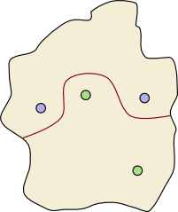

A sample dividing wall separating one group from another group

Short’s (2011) *Dividing Wall’s Theorem* presents a simplified topological equivalence to consider the conditions of segregation and isolation when a population of individuals are split into two groups. In the current instance, we will examine dissimilarity in a measure of Black and non-Black populations over some geographical area, $G$.

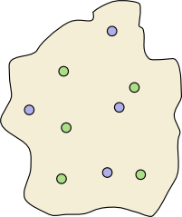

Is there a dividing wall?

> *Theorem 1.* Given any configuration of blue and green towns, there is a dividing wall that separates blue towns from green towns.

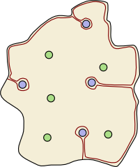

In the conceptual analysis above, there were only two tracts present and they completely segregated the two groups by the dividing wall. This conceptual model is a base example: two groups, two tracks, complete segregation.

## 1.2 Computational Model

The index of dissimilarity will be used to quantify the evenness with which Black residents are distributed relative to other non-Black racial groups across census tracts. Our current analysis builds on the perspectives that these base measures may be foundational in understanding and quantifying the dimensions of antiblackness in high-dimensional data sources.

The index of dissimilarity, $D$, is a demographic measure of the evenness with which two groups are distributed across geographic units within a larger geographical area. The measure quantifies the percentage of one group that would need to relocate to achieve an even distribution across all units in the geographical area. A value of $D = 0$ corresponds to complete integration, while $D = 1$ indicates complete segregation.

$$D = \frac{1}{2} \sum_{i=1}^N \left| \dfrac{a_i}{A} - \dfrac{b_i}{B} \right|$$

where

- $N$ is the number of geographic units (e.g., census tracts),
- $a_i$ is the population of group A (e.g., Black residents) in unit $i$,
- $A$ is the total population of group A,
- $b_i$ is the population of group B (e.g., non-Black residents) in unit $i$,
- $B$ is the total population of group B.

$D$ measures the unevenness or lack of even distribution between Black and non-Black residents across the geographical units of a region $G$. The index $D$ takes on values from $0$ (complete integration) to $1$ (complete segregation) and represents the fraction of a group’s population that would need to relocate to achieve an even spatial distribution. For example, if $D = 0.60$, 60% of one group would need to move to different areas to achieve integration.

### 1.2.1 Example: Hypothetical City Census Tracts

Consider the following hypothetical city with five census tracts.

*Table 1: Hypothetical distribution of Black ($B$) and White ($W$) households across five census tracts with intermediate calculations toward the Index of Dissimilarity.*

| Tract | $b_i$ | $w_i$ | $\dfrac{b_i}{B = 300}$ | $\dfrac{w_i}{W = 500}$ | absolute difference |
| --- | --- | --- | --- | --- | --- |
| 1 | $b_1 = 50$ | $w_1 = 10$ | 0.1667 | 0.0200 | 0.1467 |
| 2 | $b_2 = 200$ | $w_2 = 40$ | 0.6667 | 0.0800 | 0.5867 |
| 3 | $b_3 = 10$ | $w_3 = 100$ | 0.0333 | 0.2000 | 0.1667 |
| 4 | $b_4 = 30$ | $w_4 = 200$ | 0.1000 | 0.4000 | 0.3000 |
| 5 | $b_5 = 10$ | $w_5 = 150$ | 0.0333 | 0.3000 | 0.2667 |
|  |  |  |  |  | $\sum =$ 1.47 |

where,

- $B = \sum b_i = 300$ is the total number of Black households,
- $W = \sum w_i = 500$ is the total number of White households.

In Green’s example, the index of dissimilarity $D$ is computed as follows:

$$D = \frac{1}{2} \sum_{i=1}^{\textcolor{red}{N}} \left| \frac{b_i}{B} - \frac{w_i}{W} \right|$$

with $N=5$ we update our index:

$$D = \frac{1}{2} \sum_{i=1}^{\textcolor{red}{5}} \left| \frac{b_i}{B} - \frac{w_i}{W} \right|$$

we then update our population, where $B = \sum b_i = 300$ and $W = \sum w_i = 500$.

$$D = \frac{1}{2} \sum_{i=1}^{5} \left| \frac{b_i}{\textcolor{blue}{B = 300}} - \frac{w_i}{\textcolor{blue}{W = 500}} \right|$$

So we now have:

$$D = \frac{1}{2} \sum_{i=1}^5 \left| \frac{b_i}{300} - \frac{w_i}{500} \right|$$

We then subsitute our values in the expansion, starting with total populations:

$$D = \frac{1}{2} \left(
\left| \frac{b_1}{300} - \frac{w_1}{500} \right| +
\left| \frac{b_2}{300} - \frac{w_2}{500} \right| +
\left| \frac{b_3}{300} - \frac{w_3}{500} \right| +
\left| \frac{b_4}{300} - \frac{w_4}{500} \right| +
\left| \frac{b_5}{300} - \frac{w_5}{500} \right|
\right )$$

and then values from each neighborhood in the numerators:

$$D = \frac{1}{2} \left(
\left| \frac{50}{300} - \frac{10}{500} \right| +
\left| \frac{200}{300} - \frac{40}{500} \right| +
\left| \frac{10}{300} - \frac{100}{500} \right| +
\left| \frac{30}{300} - \frac{200}{500} \right| +
\left| \frac{10}{300} - \frac{150}{500} \right|
\right)$$

or, more succinctly:

$$D = \frac{1}{2} \sum_{i=1}^5 \left| \frac{b_i}{B} - \frac{w_i}{W} \right| = \frac{1}{2} (0.1467 + 0.5867 + 0.1667 + 0.3000 + 0.2667) = 0.7334$$

Green notes that 73.3 percent of either Black households would need to relocate to another tract to achieve an even distribution. In his discussion, Green first holds the White population constant in each tract and points to [Title VII of the Civil Rights Acts](https://www.eeoc.gov/statutes/title-vii-civil-rights-act-1964) when “White neighborhoods became available to Black households that previously had been constrained, by law and extra-legal practices, to live in densely populated inner cities” (Green, n.d.). He then presents the example when there is a swap to achieve racial parity across the census tracts. We modify the model and diverge from Green’s example toward another end, based on our theoretical framework centered on segregation as one measure of antiblackness (Hudson & McKittrick, 2014; King, Navarro, Smith, 2020).

# 2 Research Question

How segregated are Black residents from other racial groups across census tracts, as quantified by the index of dissimilarity, $D$?

# 3 Data and Methods

For this analysis, we will use data from the U.S. Census Bureau, which includes information from the [decennial census](https://www.census.gov/programs-surveys/decennial-census.html) and the [American Community Survey (ACS)](https://www.census.gov/programs-surveys/acs.html) 5-year estimates from the `tidycensus()` package (Walker, 2023). Additional insights are gathere from Lu et al. (2014).

There are some essential items needed to generate our maps and begin our investigations. First, please make sure you have requested and stored your [Census API key](https://api.census.gov/data/key_signup.html) for easy access. Next, you will need to get set up in R and the [R and the RStudio IDE](https://www.google.com/url?sa=t&source=web&rct=j&opi=89978449&url=https://posit.co/products/open-source/rstudio/&ved=2ahUKEwjHgNqLouWPAxX8FlkFHS1VCBoQFnoECBkQAQ&usg=AOvVaw2_EHeeDq6zN5gnktCVwGMF) (or [Posit Cloud](https://posit.cloud/)) and load the necessary packages and libraries.

Finally, you will need to select a geographical area that you would like to explore.

```r
# Install packages as needed
# install.packages(c("tidycensus", "tidyverse", "mapview", "mapgl", "quarto"))

# Load your Census
#CENSUS_API_KEY='your_api_key'

# Load necessary libraries
library(tidycensus)
library(dplyr)
library(ggplot2)
library(sf)
library(viridis)
library(scales)
```

## 3.1 Model Assumptions

We will suppose that a geographical area, $G$, consists of $N$ tracts such that
$$G = \{g_1, g_2, g_3, ...g_N\} = \{tract_1, tract_2, tract_3, ..., tract_N\}$$

where,

- $G$ is the set of census tracts that fully cover a geographical area,
- $g_i$ is the $i$-th tract such that $g_1 =$ tract 1, $g_2 =$ tract 2, $g_3 =$ tract 3, …,
- $N$ is the number of geographic units (e.g., census tracts)

We assume that $G$ can be modeled by discrete data over a minimum population of $n$ individuals, where there is at least one individual in each unit, i.e., $n \ge N$ (so that no unit in $G$ is empty, i.e., all geographical units contain at least one individual).

We also modify the group meanings in the model to attend to the theoretical framework centered on measures of segregation that support our continued understanding of antiblackness. Specifically, we have:

$$\hat{D} = \frac{1}{2} \sum_{i=1}^N \left| \dfrac{b_i}{b} - \dfrac{o_i}{O} \right|$$

where

- $N$ is the number of geographic units (e.g., census tracts),
- $b_i$ is the population of Black residents in unit $i$,
- $B$ is the total population of Black residents,
- $o_i$ is the population of non-Black (other) residents in unit $i$,
- $O$ is the total population of non-Black (other) residents.

# 4 Findings

## 4.1 DC

Given the structure of DC, we begin with `geography = "tract"`.

```r
dc_tracts <- get_acs(
  geography = "tract",
  variables = c(black = "B02001_003", # Black/African American population alone
                total = "B01001_001" # Total population
  ),
  state = "DC",
  year = 2023,
  geometry = T,
  output = "wide"
)

dc_tracts %>%
  head()
```

### 4.1.1 Black population

We then plot our data to get an initial visual of Black population.

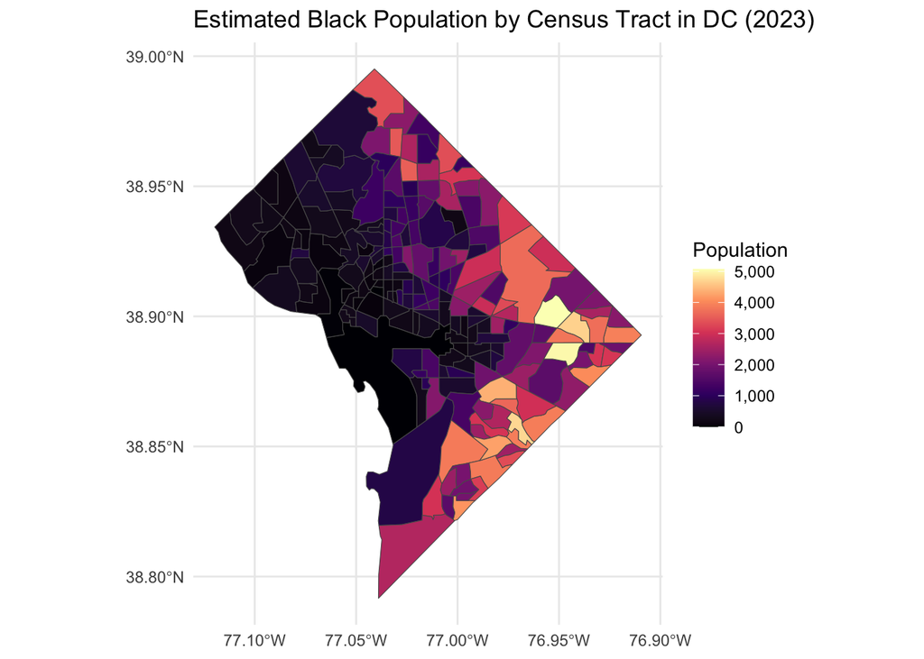

```r
ggplot(dc_tracts) +
  geom_sf(aes(fill = blackE)) +
  scale_fill_viridis_c(option = "magma",
                       na.value = "grey50",
                       labels = comma) +
  labs(title = "Estimated Black Population by Census Tract in DC (2023)",
       fill = "Population") +
  theme_minimal()
```

### 4.1.2 Non-Black population

We then create a non-black estimate.

```r
dc_tracts <- dc_tracts %>%
  mutate(nonblackE = totalE - blackE) %>%
  select(GEOID, blackE, nonblackE, totalE)
```

And the data for non-Black individuals.

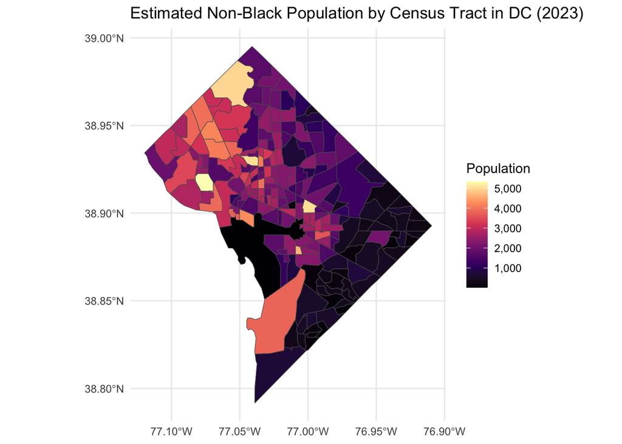

```r
ggplot(dc_tracts) +
  geom_sf(aes(fill = nonblackE)) +
  scale_fill_viridis_c(option = "magma",
                       na.value = "grey50",
                       labels = comma) +
  labs(title = "Estimated Non-Black Population by Census Tract in DC (2023)",
       fill = "Population") +
  theme_minimal()
```

Now that we know our maps feature is working, we begin our investigation.

### 4.1.3 Index of Dissimilarity

We first make a `dc_black_pop` data frame.

```r
# Get Black population by tract in DC
dc_black_pop <- get_acs(
  geography = "tract",
  variables = "B02001_003",  # Black alone
  state = "DC",
  year = 2023,
  geometry = T
) %>%
  mutate(estimate_black = estimate)
```

We then grab the total population by tract in DC, we will call it `dc_total_pop`.

```r
# Get total population by tract in DC
dc_total_pop <- get_acs(
  geography = "tract",
  variables = "B01003_001",  # total population
  state = "DC",
  year = 2023,
  geometry = F # note that we have geometry turned off here
) %>%
  mutate(estimate_total = estimate)
```

We then combine the black population with the total population.

```r
dc_combined <- left_join(dc_black_pop, dc_total_pop, by = "GEOID") %>%
  mutate(estimate_nonblack = estimate_total - estimate_black) %>%
  st_as_sf()
```

We then check our combined data with the other estimates.

```r
dc_combined %>%
  relocate(GEOID, estimate_total) %>%
  arrange(desc(estimate_black)) %>%
  head()
```

```
Simple feature collection with 6 features and 12 fields
Geometry type: POLYGON
Dimension:     XY
Bounding box:  xmin: -76.99229 ymin: 38.84459 xmax: -76.93487 ymax: 38.90822
Geodetic CRS:  NAD83
        GEOID estimate_total
1 11001009602           5527
2 11001007703           7140
3 11001007502           4999
4 11001007803           4968
5 11001007601           4949
6 11001007404           4304
                                                          NAME.x variable.x
1 Census Tract 96.02; District of Columbia; District of Columbia B02001_003
2 Census Tract 77.03; District of Columbia; District of Columbia B02001_003
```

[output cut: 25 more lines]

We then calculate the proportion of Black people in all DC tracts.

```r
total_black <- sum(dc_combined$estimate_black, na.rm = TRUE)
total_nonblack <- sum(dc_combined$estimate_nonblack, na.rm = TRUE)

dc_combined <- dc_combined %>%
  mutate(proportion_black = estimate_black / estimate_total)
```

Now we can view the top 10 tracts with the highest proportion of Black individuals.

```r
dc_combined %>%
  mutate(proportion_non_black = 1 - proportion_black) %>%
  arrange(desc(proportion_black)) %>%
  select(GEOID, proportion_black, proportion_non_black) %>%
  head(n = 10)
```

```
Simple feature collection with 10 features and 3 fields
Geometry type: POLYGON
Dimension:     XY
Bounding box:  xmin: -77.00231 ymin: 38.82144 xmax: -76.9094 ymax: 38.89661
Geodetic CRS:  NAD83
         GEOID proportion_black proportion_non_black
1  11001007404        0.9862918           0.01370818
2  11001007409        0.9834662           0.01653381
3  11001009700        0.9808168           0.01918317
4  11001009811        0.9789349           0.02106509
5  11001009905        0.9723444           0.02765556
6  11001009907        0.9666508           0.03334921
7  11001007709        0.9645701           0.03542994
8  11001007605        0.9601898           0.03981018
9  11001007808        0.9532278           0.04677223
10 11001007502        0.9469894           0.05301060
                         geometry
1  POLYGON ((-76.99199 38.8537...
2  POLYGON ((-76.98066 38.8454...
3  POLYGON ((-76.99275 38.8309...
4  POLYGON ((-77.00203 38.8309...
5  POLYGON ((-76.92932 38.8807...
6  POLYGON ((-76.94577 38.8808...
7  POLYGON ((-76.9733 38.87839...
8  POLYGON ((-76.98436 38.8666...
9  POLYGON ((-76.92796 38.8918...
10 POLYGON ((-76.97574 38.8608...
```

We can also calculate the proportion of tracts that are above a certain threshold of Black only individuals. Here we set the threshold at tracts with 75 percent or more Black residents.

```r
dc_combined %>%
  # Count how many tracts have proportion_black >= 0.75
  summarise(
    total_tracts = n(),
    tracts_above_threshold = sum(proportion_black >= 0.75),
    proportion_above_threshold = mean(proportion_black >= 0.75)
  )
```

```
Simple feature collection with 1 feature and 3 fields
Geometry type: POLYGON
Dimension:     XY
Bounding box:  xmin: -77.11976 ymin: 38.79165 xmax: -76.9094 ymax: 38.99511
Geodetic CRS:  NAD83
  total_tracts tracts_above_threshold proportion_above_threshold
1          206                     51                  0.2475728
                        geometry
1 POLYGON ((-77.05166 38.9870...
```

We see that one-fourth of all DC tracts have a population of more than 75 percent Black.

Finally, we calculate $D$.

```r
dissimilarity_dc = 0.5 * sum(abs(
  (dc_combined$estimate_black / total_black) -
  (dc_combined$estimate_nonblack / total_nonblack)
), na.rm = TRUE)
```

We print our result.

```r
dissimilarity_dc
```

```
[1] 0.5916675
```

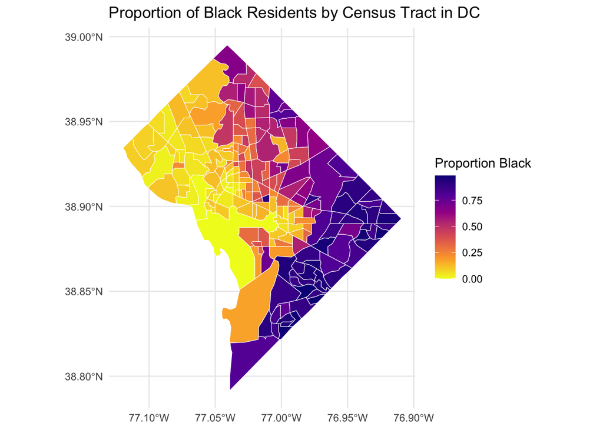

```r
# we need to manually convert our combined data frame to include simnple features
dc_combined <- st_as_sf(dc_combined)

ggplot(dc_combined) +
  geom_sf(aes(fill = proportion_black), color = "white") +
  scale_fill_viridis_c(option = "plasma", direction = -1) +
  labs(title = "Proportion of Black Residents by Census Tract in DC",
       fill = "Proportion Black") +
  theme_minimal()
```

### 4.1.4 Is there a dividing wall?

Given that our model result indicate a significant measure of segregation, we proceed with identifying the dividing wall. The maps we have viewed up to this point give us a clear view of where that wall may be.

```r
dc_combined <- dc_combined %>%
  mutate(majority_black = proportion_black > 0.5)
```

We’ll join geometries by group.

```r
# Union geometries by group
union_black <- dc_combined %>%
  filter(majority_black) %>%
  summarise(geometry = st_union(geometry))

union_nonblack <- dc_combined %>%
  filter(!majority_black) %>%
  summarise(geometry = st_union(geometry))
```

We then calculate boundary (difference) between groups (shared border).

```r
boundary_line =
  st_intersection(st_boundary(union_black), st_boundary(union_nonblack))
```

We then plot the base polygons for the dividing wall.

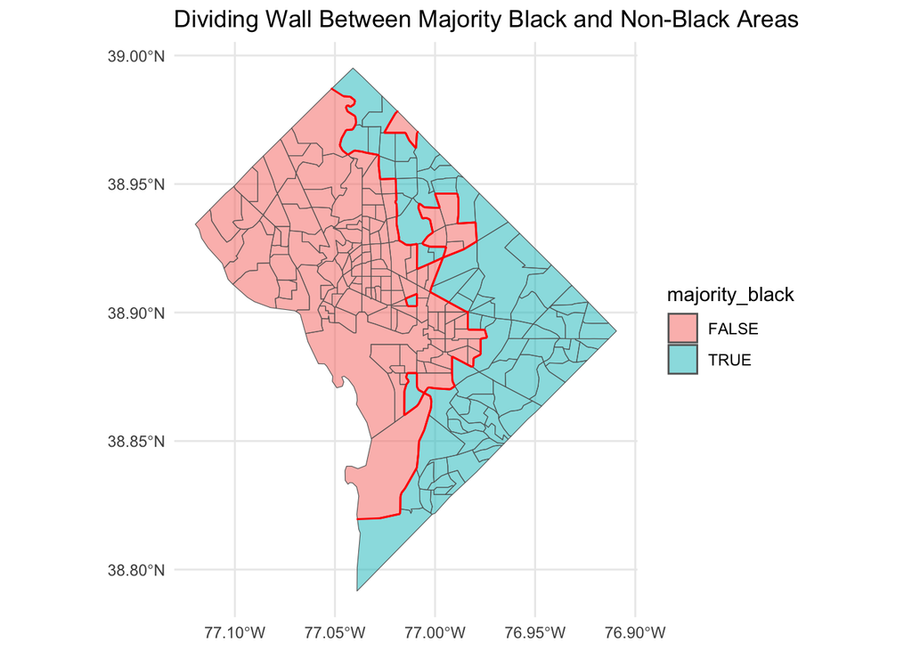

```r
ggplot() +
  geom_sf(data = dc_combined, aes(fill = majority_black),
          color = "grey40",
          alpha = 0.5) +
  geom_sf(data = boundary_line,
          color = "red",
          size = 1) +
  labs(title = "Dividing Wall Between Majority Black and Non-Black Areas") +
  theme_minimal()
```

## 4.2 NC

DC is a special case since it is a city-state.

For NC, we’ll use `geography = "county"` and then make our way down to `tracts`.

### 4.2.1 County-level data

```r
nc_counties <- get_acs(
  geography = "county",
  variables = c(black = "B02001_003", # Black/African American population alone
                total = "B01001_001" # Total population
  ),
  state = "NC",
  year = 2023,
  geometry = T,
  output = "wide"
)

# Add county FIPS code by extracting first 5 digits of GEOID
nc_counties <- nc_counties %>%
  mutate(county_fips = substr(GEOID, 1, 5)) %>%
  relocate(GEOID, county_fips)
```

We can take a `glimpse` of our data.

```r
head(nc_counties) %>%
  select(GEOID, county_fips, NAME, blackE, totalE)
```

```
Simple feature collection with 6 features and 5 fields
Geometry type: MULTIPOLYGON
Dimension:     XY
Bounding box:  xmin: -83.95288 ymin: 34.44087 xmax: -75.77333 ymax: 36.58812
Geodetic CRS:  NAD83
  GEOID county_fips                               NAME blackE totalE
1 37133       37133      Onslow County, North Carolina  26157 208537
2 37009       37009        Ashe County, North Carolina    289  26831
3 37169       37169      Stokes County, North Carolina   1543  44889
4 37053       37053   Currituck County, North Carolina   1509  29612
5 37173       37173       Swain County, North Carolina    212  14065
6 37131       37131 Northampton County, North Carolina   9451  17212
                        geometry
1 MULTIPOLYGON (((-77.17131 3...
2 MULTIPOLYGON (((-81.74065 3...
3 MULTIPOLYGON (((-80.4502 36...
4 MULTIPOLYGON (((-76.3133 36...
5 MULTIPOLYGON (((-83.94939 3...
6 MULTIPOLYGON (((-77.89977 3...
```

#### 4.2.1.1 What counties have the highest and lowest proportions of Black people?

We first view the data for counties with the largest Black populations.

```r
nc_counties %>%
  arrange(desc(blackE)) %>%
  head(n=10)
```

```
Simple feature collection with 10 features and 7 fields
Geometry type: MULTIPOLYGON
Dimension:     XY
Bounding box:  xmin: -81.4556 ymin: 34.83486 xmax: -77.08464 ymax: 36.26152
Geodetic CRS:  NAD83
   GEOID county_fips                               NAME blackE blackM  totalE
1  37119       37119 Mecklenburg County, North Carolina 344569   2725 1130906
2  37183       37183        Wake County, North Carolina 221985   2336 1151009
3  37081       37081    Guilford County, North Carolina 184691   2117  542987
4  37051       37051  Cumberland County, North Carolina 125737   1495  336749
5  37063       37063      Durham County, North Carolina 108885   1278  329405
6  37067       37067     Forsyth County, North Carolina  98592   1195  386740
7  37147       37147        Pitt County, North Carolina  60469    865  172279
8  37025       37025    Cabarrus County, North Carolina  43654   1351  231262
9  37071       37071      Gaston County, North Carolina  40681    809  231485
10 37127       37127        Nash County, North Carolina  38787    430   95451
   totalM                       geometry
1      NA MULTIPOLYGON (((-81.05803 3...
2      NA MULTIPOLYGON (((-78.98306 3...
3      NA MULTIPOLYGON (((-80.04667 3...
4      NA MULTIPOLYGON (((-79.11285 3...
5      NA MULTIPOLYGON (((-79.01207 3...
6      NA MULTIPOLYGON (((-80.51556 3...
7      NA MULTIPOLYGON (((-77.70069 3...
8      NA MULTIPOLYGON (((-80.78709 3...
9      NA MULTIPOLYGON (((-81.4556 35...
10     NA MULTIPOLYGON (((-78.2556 35...
```

Alternatively, we can view counties with large proportions of Black residents.

```r
nc_counties %>%
  mutate(prop_black = blackE / totalE) %>%
  relocate(GEOID, prop_black) %>%
  arrange(desc(prop_black))
```

```
Simple feature collection with 100 features and 8 fields
Geometry type: MULTIPOLYGON
Dimension:     XY
Bounding box:  xmin: -84.32187 ymin: 33.84232 xmax: -75.46062 ymax: 36.58812
Geodetic CRS:  NAD83
First 10 features:
   GEOID prop_black county_fips                               NAME blackE
1  37015  0.6005034       37015      Bertie County, North Carolina  10498
2  37091  0.5678313       37091    Hertford County, North Carolina  11636
3  37065  0.5591160       37065   Edgecombe County, North Carolina  27272
4  37131  0.5490937       37131 Northampton County, North Carolina   9451
5  37083  0.5192559       37083     Halifax County, North Carolina  25038
6  37187  0.4961944       37187  Washington County, North Carolina   5411
7  37181  0.4897429       37181       Vance County, North Carolina  20746
8  37007  0.4723554       37007       Anson County, North Carolina  10346
9  37185  0.4706949       37185      Warren County, North Carolina   8826
10 37117  0.4103247       37117      Martin County, North Carolina   8934
   blackM totalE totalM                       geometry
1     167  17482     NA MULTIPOLYGON (((-77.32762 3...
2     203  20492     NA MULTIPOLYGON (((-77.20861 3...
3     407  48777     NA MULTIPOLYGON (((-77.82844 3...
4     187  17212     NA MULTIPOLYGON (((-77.89977 3...
5     455  48219     NA MULTIPOLYGON (((-78.00655 3...
6     208  10905     NA MULTIPOLYGON (((-76.84726 3...
7     429  42361     NA MULTIPOLYGON (((-78.51122 3...
8     311  21903     NA MULTIPOLYGON (((-80.3102 34...
9     215  18751     NA MULTIPOLYGON (((-78.32391 3...
10    185  21773     NA MULTIPOLYGON (((-77.40261 3...
```

We see that Bertie County, NC has the highest proportion of Black people in the state, but only by a small margin. Alternatively, in the code below, we see that Yancey, Graham, Mitchell, and Haywood counties have the lowest proportion of Black people in the state.

```r
nc_counties %>%
  mutate(prop_black = blackE / totalE) %>%
  relocate(GEOID, prop_black) %>%
  arrange(-desc(prop_black))
```

```
Simple feature collection with 100 features and 8 fields
Geometry type: MULTIPOLYGON
Dimension:     XY
Bounding box:  xmin: -84.32187 ymin: 33.84232 xmax: -75.46062 ymax: 36.58812
Geodetic CRS:  NAD83
First 10 features:
   GEOID  prop_black county_fips                             NAME blackE blackM
1  37199 0.005836368       37199    Yancey County, North Carolina    109     76
2  37075 0.006964308       37075    Graham County, North Carolina     56     80
3  37121 0.007880852       37121  Mitchell County, North Carolina    118     68
4  37087 0.009994874       37087   Haywood County, North Carolina    624    198
5  37115 0.010304991       37115   Madison County, North Carolina    223     89
6  37009 0.010771123       37009      Ashe County, North Carolina    289    100
7  37113 0.011882876       37113     Macon County, North Carolina    446    181
8  37005 0.014808126       37005 Alleghany County, North Carolina    164     95
9  37173 0.015072876       37173     Swain County, North Carolina    212    112
10 37039 0.015378292       37039  Cherokee County, North Carolina    449     85
   totalE totalM                       geometry
1   18676     NA MULTIPOLYGON (((-82.50538 3...
2    8041     NA MULTIPOLYGON (((-84.03815 3...
3   14973     NA MULTIPOLYGON (((-82.41666 3...
4   62432     NA MULTIPOLYGON (((-83.25611 3...
5   21640     NA MULTIPOLYGON (((-82.96221 3...
6   26831     NA MULTIPOLYGON (((-81.74065 3...
7   37533     NA MULTIPOLYGON (((-83.73709 3...
8   11075     NA MULTIPOLYGON (((-81.35326 3...
9   14065     NA MULTIPOLYGON (((-83.94939 3...
10  29197     NA MULTIPOLYGON (((-84.31749 3...
```

These maps will vary by state, and there are many directions to go to from this point. For example we could do some of the following:

- Examine counties with the highest proprtion of Black residents and gather a measure of residential segregation,
- Examine counties with the lowest proportion of Black residents and gather a measure of residential segregation,
- Look specifically at those counties with high numbers of white individuals as a proxy for other to assess the relationship to counties with low or high proportion of Black individuals as a basic model of segregation

Here is where theory meets our computational practice.

### 4.2.2 Mecklenburg County, NC

I will select my home county: Mecklenburg County, NC for further investigation.

```r
meck_tracts <- get_acs(
  geography = "tract",
  variables = c(
    black = "B02001_003",      # Black or African American alone
    total = "B01001_001"       # Total population
  ),
  state = "NC",
  county = "Mecklenburg",
  year = 2023,
  geometry = TRUE,
  output = "wide"
)

meck_tracts %>%
  head()
```

#### 4.2.2.1 Black population

We then plot our data to get an initial visual of Black population.

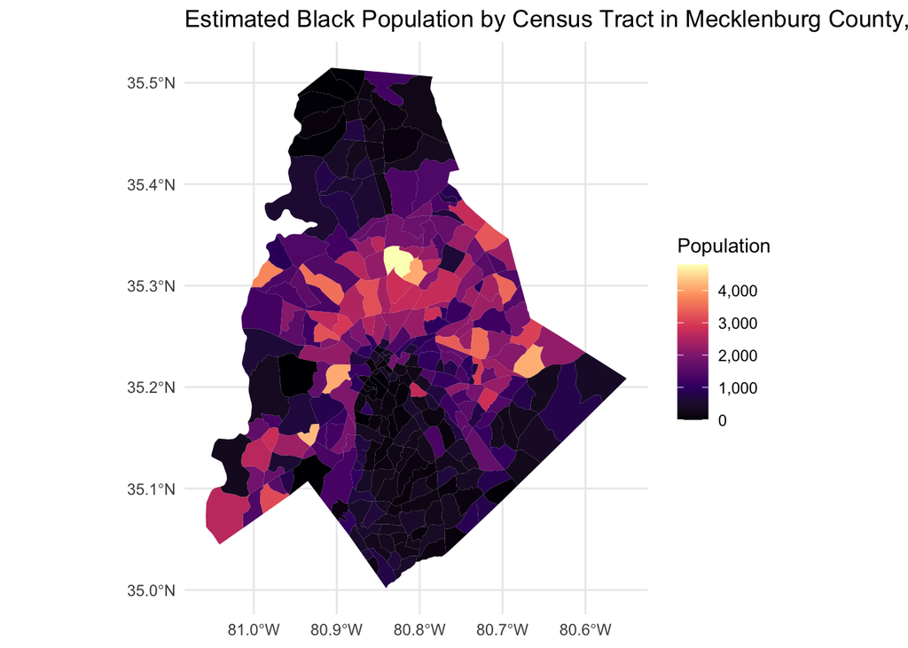

```r
ggplot(meck_tracts) +
  geom_sf(aes(fill = blackE), color = NA) +
  scale_fill_viridis_c(option = "magma", na.value = "grey50", labels = comma) +
  labs(title = "Estimated Black Population by Census Tract in Mecklenburg County, NC (2023)",
       fill = "Population") +
  theme_minimal()
```

#### 4.2.2.2 Non-Black population

We then create a non-black estimate.

```r
meck_tracts <- meck_tracts %>%
  mutate(nonblackE = totalE - blackE) %>%
  select(GEOID, blackE, nonblackE, totalE)
```

And the data for non-Black individuals.

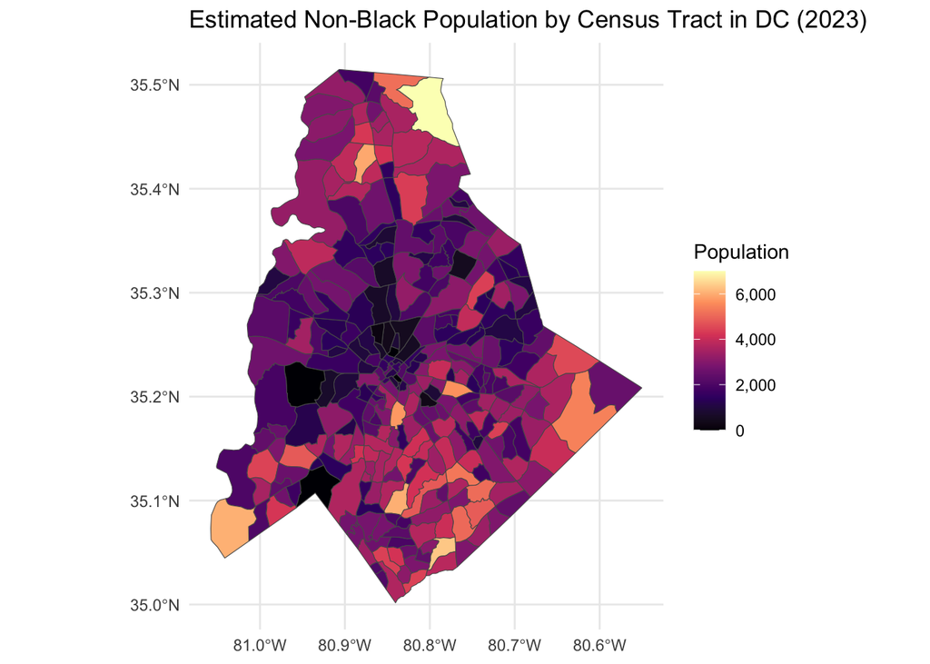

```r
ggplot(meck_tracts) +
  geom_sf(aes(fill = nonblackE)) +
  scale_fill_viridis_c(option = "magma",
                       na.value = "grey50",
                       labels = comma) +
  labs(title = "Estimated Non-Black Population by Census Tract in DC (2023)",
       fill = "Population") +
  theme_minimal()
```

### 4.2.3 Index of Dissimilarity

We can calculate the proportion of Black people in all Mecklenburg tracts.

```r
meck_tracts <- meck_tracts %>%
  mutate(proportion_black = blackE / totalE) %>%
  mutate(proportion_non_black = 1 - proportion_black)
```

Now we can view the top 10 tracts with the highest proportion of Black individuals.

```r
meck_tracts %>%
  arrange(desc(proportion_black)) %>%
  select(GEOID, proportion_black, proportion_non_black) %>%
  head(n = 10)
```

```
Simple feature collection with 10 features and 3 fields
Geometry type: MULTIPOLYGON
Dimension:     XY
Bounding box:  xmin: -81.00385 ymin: 35.18978 xmax: -80.7906 ymax: 35.33573
Geodetic CRS:  NAD83
         GEOID proportion_black proportion_non_black
1  37119004900        0.9701754           0.02982456
2  37119004600        0.9447784           0.05522164
3  37119002300        0.8961385           0.10386152
4  37119004800        0.8598303           0.14016968
5  37119005406        0.8340760           0.16592398
6  37119005100        0.8217456           0.17825444
7  37119003902        0.8122643           0.18773566
8  37119006013        0.7819954           0.21800456
9  37119006109        0.7739774           0.22602257
10 37119005200        0.7151767           0.28482328
                         geometry
1  MULTIPOLYGON (((-80.8505 35...
2  MULTIPOLYGON (((-80.87003 3...
3  MULTIPOLYGON (((-80.81155 3...
4  MULTIPOLYGON (((-80.85648 3...
5  MULTIPOLYGON (((-80.87669 3...
6  MULTIPOLYGON (((-80.84674 3...
7  MULTIPOLYGON (((-80.91716 3...
8  MULTIPOLYGON (((-81.00183 3...
9  MULTIPOLYGON (((-80.86684 3...
10 MULTIPOLYGON (((-80.84089 3...
```

As we did before, we can also calculate the proportion of tracts that are above a certain threshold of Black only individuals. Here we set the threshold at tracts with 60 percent or more Black residents given the size of the state.

Note that we need to remove the geometry feature before summarizing.

```r
meck_tracts %>%
  st_set_geometry(NULL) %>%   # Remove geometry to treat as normal data.frame
  summarise(
    total_tracts = n(),
    tracts_above_threshold = sum(proportion_black >= 0.60, na.rm = TRUE),
    proportion_above_threshold = mean(proportion_black >= 0.60, na.rm = TRUE)
  )
```

```
  total_tracts tracts_above_threshold proportion_above_threshold
1          305                     34                  0.1122112
```

Finally, we calculate $D$ for the county.

```r
meck_total_black <- sum(meck_tracts$blackE, na.rm = TRUE)
meck_total_nonblack <- sum(meck_tracts$nonblackE, na.rm = TRUE)

dissimilarity_meck <- 0.5 * sum(abs(
  (meck_tracts$blackE / total_black) -
  (meck_tracts$nonblackE / total_nonblack)
), na.rm = TRUE)
```

We print our result.

```r
dissimilarity_meck
```

```
[1] 0.7394032
```

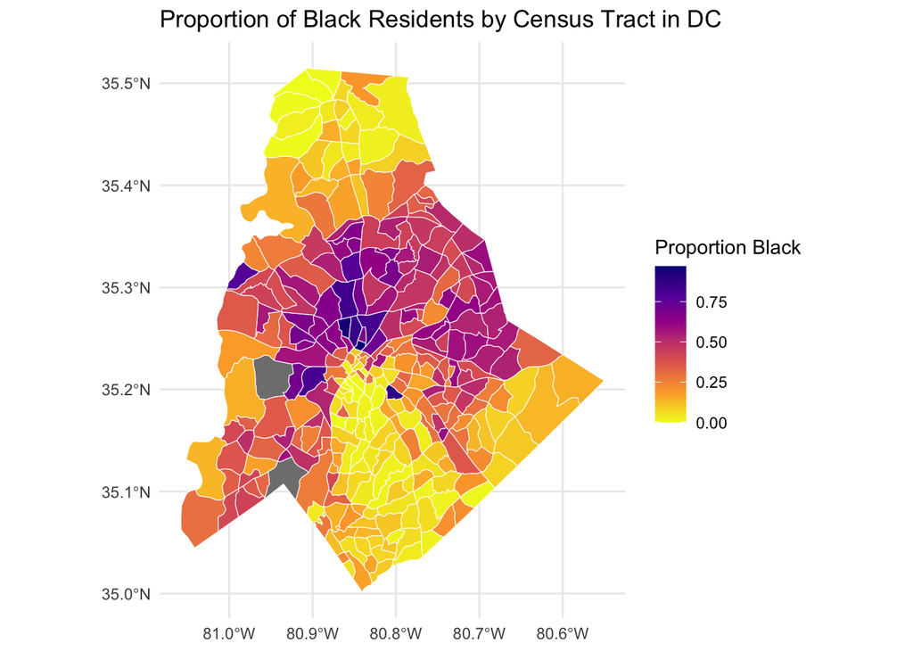

```r
ggplot(meck_tracts) +
  geom_sf(aes(fill = proportion_black), color = "white") +
  scale_fill_viridis_c(option = "plasma", direction = -1) +
  labs(title = "Proportion of Black Residents by Census Tract in DC",
       fill = "Proportion Black") +
  theme_minimal()
```

### 4.2.4 Is there a dividing wall?

Given that our model result indicate a significant measure of segregation, we proceed with identifying the dividing wall. The maps we have viewed up to this point give us a clear view of where that wall may be.

```r
meck_tracts <- meck_tracts %>%
  mutate(majority_black = proportion_black > 0.5)
```

We’ll join geometries by group.

```r
# Union geometries by group
meck_union_black <- meck_tracts %>%
  filter(majority_black) %>%
  summarise(geometry = st_union(geometry))

meck_union_nonblack <- meck_tracts %>%
  filter(!majority_black) %>%
  summarise(geometry = st_union(geometry))
```

We then calculate boundary (difference) between groups (shared border).

```r
meck_boundary_line =
  st_intersection(st_boundary(meck_union_black), st_boundary(meck_union_nonblack))
```

We then plot the base polygons for the dividing wall.

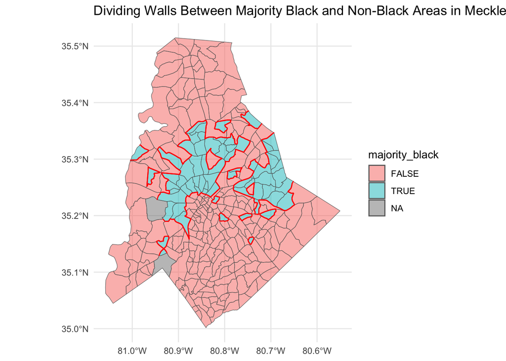

```r
ggplot() +
  geom_sf(data = meck_tracts, aes(fill = majority_black),
          color = "grey40",
          alpha = 0.5) +
  geom_sf(data = meck_boundary_line,
          color = "red",
          size = 1) +
  labs(title = "Dividing Walls Between Majority Black and Non-Black Areas in Mecklenburg County, NC") +
  theme_minimal()
```

From an analysis of history regarding the region, and contextual knowledge about the urban make-up of Charlotte, NC, which is the major proportion of the area, there is clear evidence of white flight given the shape of the dividing wall.

Where might you go from here?

# 5 References

Hudson, P. J., & McKittrick, K. (2014). The geographies of blackness and anti-blackness. *The CLR James Journal, 20*(1/2), 233–240.

King, T. L., Navarro, J., & Smith, A. (2020). *Otherwise worlds: Against settler colonialism and anti-blackness*. [Duke University Press.](https://dukeupress.edu/otherwise-worlds)

Lu, B., Harris, P., Charlton, M., & Brunsdon, C. (2014). The GWmodel R package: Further topics for exploring spatial heterogeneity using geographically weighted models. [*Geo-Spatial Information Science, 17*(2), 85–101.](https://www.tandfonline.com/doi/full/10.1080/10095020.2014.928460)

Sørensen, A. B. (1978). Mathematical models in sociology. [*Annual Review of Sociology, 4*, 345–371.](https://www.annualreviews.org/doi/10.1146/annurev.so.04.080178.002021)

Walker, K. (2023). *Analyzing US census data: Methods, maps, and models in R*. [Chapman.](https://walker-data.com/census-r/)

# 6 Coda

While the index of dissimilarity offers a clear and interpretable measure of segregation, it is only one facet of complex social dynamics. Future work could extend this analysis by incorporating:

- Isolation and clustering indices to capture different aspects of segregation.
- Temporal dynamics to assess how patterns shift over time.
- Qualitative data integration to contextualize spatial patterns with lived experiences.
- Policy evaluation assessing impacts of urban planning and housing initiatives.

This technical file lays the foundation for quantitative historical geography research by demonstrating reproducible workflows with open Census data and modern R tools. The methodologies presented can be readily adapted to other metropolitan areas and demographic groups for comparative analyses.

Continued interdisciplinary collaboration will deepen our understanding of spatial inequality and support informed efforts to foster equitable communities.

Document ID: 20250922-na